# Fancy interactive tables in R with reactable

Creating visually appealing tables and visualizations is an asset for any data analyst, especially when the findings have to be presented to the stakeholders or, in general, to a broad audience. In this way, R has some libraries that make this really simple. That is the case with `reactable` library, which makes it very easy to design very attractive interactive tables. I’ll be using this library along with `reactablefmtr`, which adds even more functionalities to create these tables.

This time, I’ll be using scraped data that contains relevant information about commuter and regional trains run by RENFE in Catalonia to showcase delay metrics for the different train lines. The resulting table will look just like that in the image below.

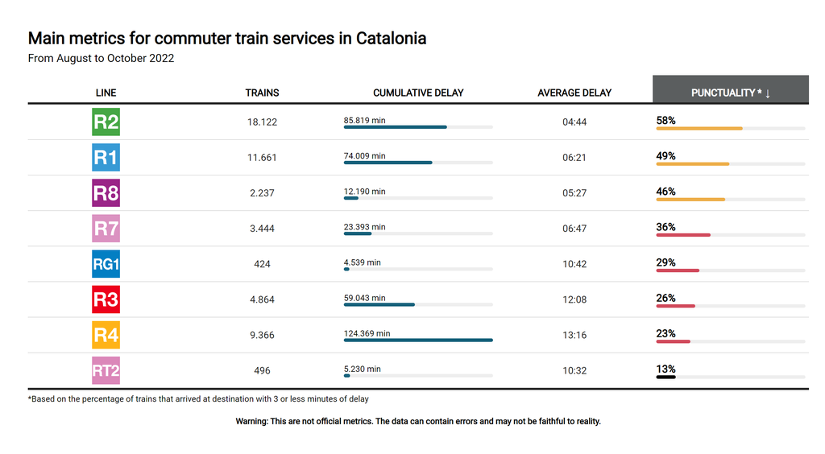

## Importing the data

Since the data is stored locally on a PostgreSQL database, I will first query the database to retrieve the needed table.

```r
# Libraries
library(tidyverse)
library(reactable)
library(reactablefmtr)
library(scales)
library(RPostgres)

# Data import
con <- dbConnect(RPostgres::Postgres(),
                 dbname = "traindb",
                 host = "localhost",
                 port = "5432",
                 user = Sys.getenv("TRAIN_LOCALDB_USER"),
                 password = Sys.getenv("TRAIN_LOCALPWD"))

data <- dbGetQuery(con, "SELECT * FROM train_data")
```

## Data wrangling

To create the tables I’ll be using only some basic aggregated information, including the train line and delay-related data calculated using the `last_stop_delay` column, such as the cumulative delay in minutes, the average delay and the punctuality by line. In this case, I’ll be filtering those trains that appear as cancelled or disabled. Also, I’ll be replacing negative delays with a 0 (train arrived early to destination) to prevent disorting the metrics.

When it comes to the punctuality measure, a different threshold is set for commuter and regional trains. More than 3 minutes delay at the destination is considered the threshold for commuter trains, which goes up to 5 minutes for regional trains. The criteria used to establish which trains are effectively considered delayed at the destination is the same as that used by RENFE [[See here](https://rodalies.gencat.cat/ca/sobre-rodalies/que-son-rodalies-de-catalunya/index.html)]

In addition, I’ll add two extra columns to the table to make it more visually appealing; a column containing the URL for each line’s logo, which will be rendered in the final table, and a column listing which hexadecimal colour should take on the punctuality value based on the different thresholds.

```r
# Data wrangling
table_data <- data %>%
  select(
    line,
    last_stop_delay,
    is_pmr,
    is_cancelled,
    is_disabled,
    data_timestamp
  ) %>%
  filter(
    is_disabled == FALSE,
    is_cancelled == FALSE,
    data_timestamp < as.POSIXct("2022-11-01 00:00:00")
    ) %>%
  group_by(
    line
    ) %>%
  mutate(
    last_stop_delay = replace(last_stop_delay, last_stop_delay < 0, 0),
    service_type = case_when(
      line %in% c("R1", "R2", "R3", "R4", "R7", "R8", "RG1", "RT1", "RT2") ~ "Commuter",
      line %in% c("R11","R12", "R13", "R14", "R15", "R16", "R17", "MD") ~ "Regional"
    ),
    is_delay = case_when(
      last_stop_delay > 3 & service_type == "Commuter" ~ TRUE,
      last_stop_delay > 5 & service_type == "Regional" ~ TRUE,
      TRUE ~ FALSE)
    ) %>%
  summarise(
    avg_delay = round(mean(last_stop_delay), 2),
    median_delay = median(last_stop_delay),
    cumulative_delay = sum(last_stop_delay),
    punctuality = 100 - round((sum(is_delay) / n())*100, 1),
    trains = n()
    )

## Additional values for commuter trains table
img_path <- "https://upload.wikimedia.org/wikipedia/commons/thumb/"

table_commuter <- table_data %>%
  filter(
    line %in% c("R1", "R2", "R3", "R4", "R7", "R8", "RG1", "RT1", "RT2")
    ) %>%
  mutate(
    avg_delay = strftime(as.POSIXct(avg_delay * 60, origin = Sys.Date(), tz = "GMT"), format = "%M:%S"),
    line_logo = case_when(
      line == "R1" ~ paste0(img_path, "f/fa/R1_barcelona.svg/1280px-R1_barcelona.svg.png"),
      line == "R2" ~ paste0(img_path, "6/63/R2_barcelona.svg/1280px-R2_barcelona.svg.png"),
      line == "R3" ~ paste0(img_path, "e/ec/R3_barcelona.svg/1280px-R3_barcelona.svg.png"),
      line == "R4" ~ paste0(img_path, "a/a1/R4_barcelona.svg/1280px-R4_barcelona.svg.png"),
      line == "R7" ~ paste0(img_path, "c/c0/R7_barcelona.svg/1280px-R7_barcelona.svg.png"),
      line == "R8" ~ paste0(img_path, "1/14/R8_barcelona.svg/1280px-R8_barcelona.svg.png"),
      line == "RG1" ~ paste0(img_path, "e/e4/RG1_girona.svg/1280px-RG1_girona.svg.png"),
      line == "RT1" ~ paste0(img_path, "8/86/RT1_tarragona.svg/1280px-RT1_tarragona.svg.png"),
      line == "RT2" ~ paste0(img_path, "1/11/RT2_tarragona.svg/1280px-RT2_tarragona.svg.png")
      ),
    punctuality_color = case_when(
      punctuality < 20 ~ "#000000",
      punctuality >= 20 & punctuality < 40 ~ "#d1495b",
      punctuality >= 40 & punctuality < 60 ~ "#edae49",
      punctuality >= 60 & punctuality < 80 ~ "#66a182",
      punctuality >= 80 ~ "#00798c"
    )
  )

## Additional values for regional trains table
table_regional <- table_data %>%
  filter(
    line %in% c("R11", "R12", "R13", "R14", "R15", "R16", "R17", "MD")
  ) %>%
  mutate(
    avg_delay = strftime(as.POSIXct(avg_delay * 60, origin = Sys.Date(), tz = "GMT"), format = "%M:%S"),
    line_logo = case_when(
      line == "R11" ~ paste0(img_path, "0/0d/R11_Rodalies_de_Catalunya.svg/1280px-R11_Rodalies_de_Catalunya.svg.png"),
      line == "R12" ~ paste0(img_path, "7/70/R12_Rodalies_de_Catalunya.svg/1280px-R12_Rodalies_de_Catalunya.svg.png"),
      line == "R13" ~ paste0(img_path, "7/74/R13_Rodalies_de_Catalunya.svg/1280px-R13_Rodalies_de_Catalunya.svg.png"),
      line == "R14" ~ paste0(img_path, "2/28/R14_Rodalies_de_Catalunya.svg/1280px-R14_Rodalies_de_Catalunya.svg.png"),
      line == "R15" ~ paste0(img_path, "f/fb/R15_Rodalies_de_Catalunya.svg/1280px-R15_Rodalies_de_Catalunya.svg.png"),
      line == "R16" ~ paste0(img_path, "7/76/R16_Rodalies_de_Catalunya.svg/1280px-R16_Rodalies_de_Catalunya.svg.png"),
      line == "R17" ~ paste0(img_path, "a/ab/R17_Rodalies_de_Catalunya.svg/1280px-R17_Rodalies_de_Catalunya.svg.png"),
      line == "MD" ~ paste0("https://upload.wikimedia.org/wikipedia/commons/0/01/Logo%2C_Renfe_Media_distancia.PNG")
    ),
    punctuality_color = case_when(
      punctuality < 20 ~ "#000000",
      punctuality >= 20 & punctuality < 40 ~ "#d1495b",
      punctuality >= 40 & punctuality < 60 ~ "#edae49",
      punctuality >= 60 & punctuality < 80 ~ "#66a182",
      punctuality >= 80 ~ "#00798c"
    )
  )
```

## Creating the tables

It’s finally time to create the tables. This time I’ll be creating two tables; one for commuter trains and the other for regional trains, both containing the same measures.

First, I’ll be using a `select` statement to specify column order, as the reactable function doesn’t seem to include an option to do it. After that, I’ll be calling the `reactable` function to create the table, customizing some parameters to add little visuals, and in general a more vibely table.

### Commuter’s table

```r
# Reactable for commuter trains
table_commuter %>%
  select(
    line_logo,
    trains,
    cumulative_delay,
    avg_delay,
    punctuality,
    punctuality_color
    ) %>%
  reactable(
    theme = fivethirtyeight(
      header_font_size = 14,
      centered = TRUE),
    defaultSorted = "punctuality",
    defaultSortOrder = "desc",
    defaultColDef = colDef(
      align = "center",
      minWidth = 50
    ),
    columns = list(
      punctuality = colDef(
        name = "Punctuality *",
        cell = data_bars(
          table_commuter,
          max_value = 100,
          min_value = 0,
          text_position = "above",
          text_size = 15,
          round_edges = TRUE,
          bold_text = TRUE,
          fill_color_ref = "punctuality_color",
          number_fmt = scales::number_format(suffix = "%"))
      ),
      line_logo = colDef(
        name = "Line",
        html = TRUE,
        cell = embed_img(
          data = line_logo,
          height = 40,
          width = 40)
      ),
      trains = colDef(
        cell = scales::number_format(big.mark = ".", decimal.mark = ","),
        style = cell_style(
          horizontal_align = "center",
          vertical_align = "center")
      ),
      cumulative_delay = colDef(
        name = "Cumulative delay",
        cell = data_bars(
          table_commuter,
          text_position = "above",
          text_size = 12,
          round_edges = TRUE,
          number_fmt = scales::number_format(suffix = " min", big.mark = ".", decimal.mark = ","))
      ),
      avg_delay = colDef(
        name = "Average delay",
        cell = color_tiles(table_commuter),
        style = cell_style(
          horizontal_align = "center",
          vertical_align = "center")
      ),
      punctuality_color = colDef(
        show = FALSE
      )
    )
  ) %>%
  add_title(title = "Main metrics for commuter train services in Catalonia",
            font_size = 24) %>%
  add_subtitle(subtitle = "From August to October 2022",
               font_size = 16,
               font_weight = "normal",
               margin = margin(t = 5, b = 15)) %>%
  add_source(source = "*Based on the percentage of trains that arrived at destination with 3 or less minutes of delay",
             font_size = 12,
             margin = margin(t = 6)) %>%
  add_source(source = "Warning:  This are not official metrics. The data can contain errors and may not be faithful to reality.",
             font_size = 12,
             font_weight = "bold",
             align = "center",
             margin = margin(t = 18)) %>%
  google_font(font_family = "Roboto")
```

# Main metrics for commuter train services in Catalonia

## From August to October 2022

| Line | trains | Cumulative delay | Average delay | Punctuality * |
| --- | --- | --- | --- | --- |
| https://upload.wikimedia.org/wikipedia/commons/thumb/f/fa/R1_barcelona.svg/1280px-R1_barcelona.svg.png | 11661 | 74009 | 06:21 | 49.2 |
| https://upload.wikimedia.org/wikipedia/commons/thumb/6/63/R2_barcelona.svg/1280px-R2_barcelona.svg.png | 18122 | 85819 | 04:44 | 58 |
| https://upload.wikimedia.org/wikipedia/commons/thumb/e/ec/R3_barcelona.svg/1280px-R3_barcelona.svg.png | 4864 | 59043 | 12:08 | 26.4 |
| https://upload.wikimedia.org/wikipedia/commons/thumb/a/a1/R4_barcelona.svg/1280px-R4_barcelona.svg.png | 9366 | 124369 | 13:16 | 23.1 |
| https://upload.wikimedia.org/wikipedia/commons/thumb/c/c0/R7_barcelona.svg/1280px-R7_barcelona.svg.png | 3444 | 23393 | 06:47 | 36.4 |
| https://upload.wikimedia.org/wikipedia/commons/thumb/1/14/R8_barcelona.svg/1280px-R8_barcelona.svg.png | 2237 | 12190 | 05:27 | 46.2 |
| https://upload.wikimedia.org/wikipedia/commons/thumb/e/e4/RG1_girona.svg/1280px-RG1_girona.svg.png | 424 | 4539 | 10:42 | 29.2 |
| https://upload.wikimedia.org/wikipedia/commons/thumb/1/11/RT2_tarragona.svg/1280px-RT2_tarragona.svg.png | 496 | 5230 | 10:32 | 12.9 |

*Based on the percentage of trains that arrived at destination with 3 or less minutes of delay

Warning: This are not official metrics. The data can contain errors and may not be faithful to reality.

### Regional’s table

Now is the time to do the same for the regional trains table. To do so, I’ll be using almost the same code used in the previous table, just changing the title and some other text.

```r
# Reactable for regional trains
table_regional %>%
  select(
    line_logo,
    trains,
    cumulative_delay,
    avg_delay,
    punctuality,
    punctuality_color
  ) %>%
  reactable(
    theme = fivethirtyeight(
      header_font_size = 14,
      centered = TRUE),
    defaultSorted = "punctuality",
    defaultSortOrder = "desc",
    defaultColDef = colDef(
      align = "center",
      minWidth = 50
    ),
    columns = list(
      punctuality = colDef(
        name = "Punctuality *",
        cell = data_bars(
          table_regional,
          max_value = 100,
          min_value = 0,
          text_position = "above",
          text_size = 15,
          round_edges = TRUE,
          bold_text = TRUE,
          fill_color_ref = "punctuality_color",
          number_fmt = scales::number_format(suffix = "%"))
      ),
      line_logo = colDef(
        name = "Line",
        html = TRUE,
        cell = embed_img(
          data = line_logo,
          height = 40,
          width = 40)
      ),
      trains = colDef(
        cell = scales::number_format(big.mark = ".", decimal.mark = ","),
        style = cell_style(
          horizontal_align = "center",
          vertical_align = "center")
      ),
      cumulative_delay = colDef(
        name = "Cumulative delay",
        cell = data_bars(
          table_regional,
          text_position = "above",
          text_size = 12,
          round_edges = TRUE,
          number_fmt = scales::number_format(suffix = " min", big.mark = ".", decimal.mark = ","))
      ),
      avg_delay = colDef(
        name = "Average delay",
        cell = color_tiles(table_regional),
        style = cell_style(
          horizontal_align = "center",
          vertical_align = "center")
      ),
      punctuality_color = colDef(
        show = FALSE
      )
    )
  ) %>%
  add_title(title = "Main metrics for regional train services in Catalonia",
            font_size = 24) %>%
  add_subtitle(subtitle = "From August to October 2022",
               font_size = 16,
               font_weight = "normal",
               margin = margin(t = 5, b = 15)) %>%
  add_source(source = "*Based on the percentage of trains that arrived at destination with 5 or less minutes of delay",
             font_size = 12,
             margin = margin(t = 6)) %>%
  add_source(source = "Warning:  This are not official metrics. The data can contain errors and may not be faithful to reality.",
             font_size = 12,
             font_weight = "bold",
             align = "center",
             margin = margin(t = 18)) %>%
  google_font(font_family = "Roboto")
```

# Main metrics for regional train services in Catalonia

## From August to October 2022

| Line | trains | Cumulative delay | Average delay | Punctuality * |
| --- | --- | --- | --- | --- |
| https://upload.wikimedia.org/wikipedia/commons/0/01/Logo%2C_Renfe_Media_distancia.PNG | 561 | 4208 | 07:30 | 67.6 |
| https://upload.wikimedia.org/wikipedia/commons/thumb/0/0d/R11_Rodalies_de_Catalunya.svg/1280px-R11_Rodalies_de_Catalunya.svg.png | 3081 | 20625 | 06:41 | 66.3 |
| https://upload.wikimedia.org/wikipedia/commons/thumb/7/70/R12_Rodalies_de_Catalunya.svg/1280px-R12_Rodalies_de_Catalunya.svg.png | 427 | 3950 | 09:15 | 49.9 |
| https://upload.wikimedia.org/wikipedia/commons/thumb/7/74/R13_Rodalies_de_Catalunya.svg/1280px-R13_Rodalies_de_Catalunya.svg.png | 422 | 4010 | 09:30 | 52.8 |
| https://upload.wikimedia.org/wikipedia/commons/thumb/2/28/R14_Rodalies_de_Catalunya.svg/1280px-R14_Rodalies_de_Catalunya.svg.png | 640 | 3854 | 06:01 | 73.3 |
| https://upload.wikimedia.org/wikipedia/commons/thumb/f/fb/R15_Rodalies_de_Catalunya.svg/1280px-R15_Rodalies_de_Catalunya.svg.png | 1592 | 12802 | 08:02 | 72.1 |
| https://upload.wikimedia.org/wikipedia/commons/thumb/7/76/R16_Rodalies_de_Catalunya.svg/1280px-R16_Rodalies_de_Catalunya.svg.png | 1270 | 8171 | 06:25 | 76.1 |
| https://upload.wikimedia.org/wikipedia/commons/thumb/a/ab/R17_Rodalies_de_Catalunya.svg/1280px-R17_Rodalies_de_Catalunya.svg.png | 590 | 4446 | 07:32 | 68.8 |

*Based on the percentage of trains that arrived at destination with 5 or less minutes of delay

Warning: This are not official metrics. The data can contain errors and may not be faithful to reality.